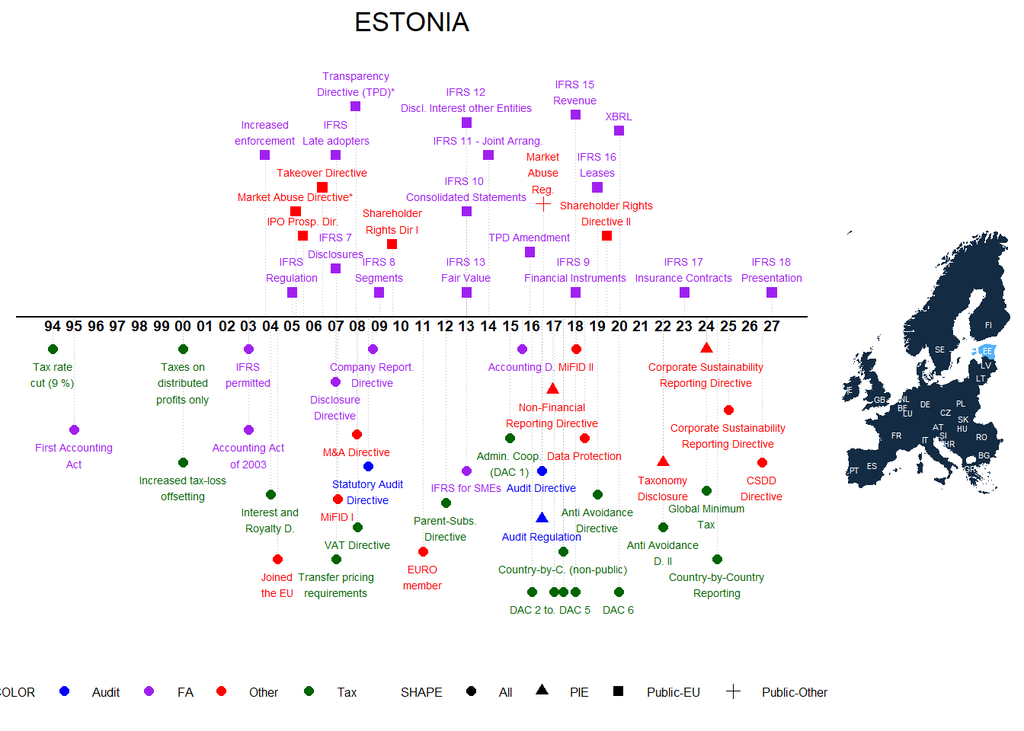

Notes: The graph depicts major regulatory changes that we identified via an extensive literature search, an online survey of mentioned authors, and other sources. Please note that the graph does not include all possible regulatory changes, e.g. minor revisions to local GAAP or tax rate changes below 3% are not included. The dates of EU Directives are based on the official transposition deadlines unless denoted with a *, in which case we included the entry-to-force date as identified in the literature. For more information, please go to [Labro and Pierk (2023)](http://www.eu-regulations.com/Labro_Pierk_2023.pdf). We kindly ask that you cite the paper if you use the information on this website in your research project. Do you have comments or see anything missing? Please email us!

## Regulations, Publications, Further Graphs

The tab ‘Regulations’ includes links to the regulations, gives short descriptions, and provides selective papers for further reading. If the regulation is a national transposition of an EU Directive, the link to the Directive is given. The tab ‘Number of Regulations’ shows graphically the number of regulations 8 years around the respective year (-4,-3,-2,-1,0,+1,+2,+3). The tab ‘Number of Categories” shows graphically the number of different categories 8 years around the respective year (-4,-3,-2,-1,0,+1,+2,+3). The tab ’Publications’ shows all publications that include the countries’ names and variations thereof in the title, abstract, or keywords. Similarly, the tab ‘SSRN’ shows papers of the SSRN Accouning Research Network that include the countries’ names and variations.

### Regulations

|  | Date | Milestones | Applies_to | Category | Description |
| --- | --- | --- | --- | --- | --- |
| 1 | 1994-01-01 | Tax rate cut (9 %) | All Firms | Tax | Tax rate cut (9 %): Estonia reduced the corporate tax rate by 9 percentage points (from 35 to 26 percent). |
| 2 | 1995-01-01 | First Accounting Act | All Firms | FA | Raamatupidamise seadus 1995 (Accounting Act 1995): Defined the basic mandatory accounting and reporting requirements. See also: Alver and Alver 2017 |
| 3 | 2000-01-01 | Taxes on distributed profits only | All Firms | Tax | Tulumaksuseadus 2000 (Income tax act 2000): Corporate tax is based on distributed, but not on reinvested profits. |
| 4 | 2000-01-01 | Increased tax-loss offsetting | All Firms | Tax | Increased tax-loss offsetting: Tax loss carryforwards was increased from 5 to 7 years. See also: Dreßler and Overesch 2013 |
| 5 | 2003-01-01 | IFRS permitted | All Firms | FA | IFRS permitted: IFRS permitted for consolidated and unconsolidated financial statements (required for some). See also: Balsmeier and Vanhaverbeke 2018; Alver and Alver 2017; André 2017 |
| 6 | 2003-01-01 | Accounting Act of 2003 | All Firms | FA | Raamatupidamise seadus 2003 (Accounting Act 2003): "The purpose of the AA 2003 was to create the legal bases and establish general requirements for organizing accounting and financial reporting pursua… |
| 7 | 2003-10-01 | Increased enforcement | Public-EU | FA | Increased enforcement: Increased enforcement in 2003 Q4: "The Estonian Financial Supervision Authority (EFSA) dedicated one staff member to the enforcement of compliance with accounting standards in O… |
| 8 | 2004-05-01 | Joined the EU | All Firms | Other | Joined the EU: Joined the European Union. |
| 9 | 2004-05-01 | Interest and Royalty D. | All Firms | Tax | TULUMAKSUSEADUSE, KOHALIKE MAKSUDE SEADUSE JA MAKSUKORRALDUSE SEADUSE MUUTMISE SEADUS1 (AMENDMENTS TO THE INCOME TAX ACT, THE LOCAL TAX ACT AND THE TAX ADMINISTRATION ACT1 ): Exemption from tax on int… |
| 10 | 2005-01-01 | IFRS Regulation | Public-EU | FA | Regulation 1606/2002: Firms listed on EU-regulated markets are required to use the International Financial Reporting Standards (IFRS) for their consolidated financial statements. Firms that use US GAA… |

[output cut: 52 more lines]

### Number of Regulations

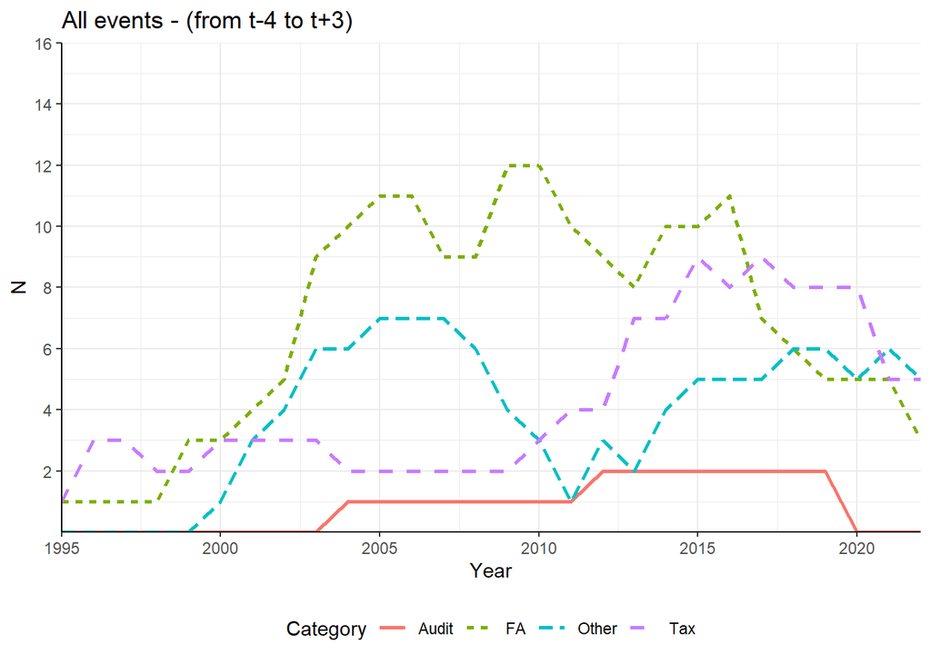

### Number of Categories

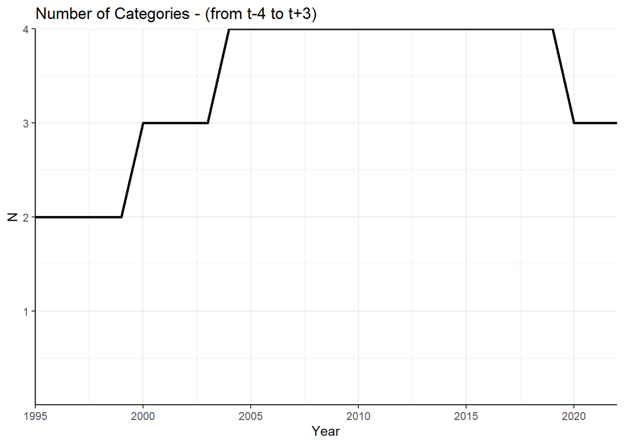

### Publications

|  | authors | title | year | journal |
| --- | --- | --- | --- | --- |
| 1 | Alver L., Alver J. | the role and current status of ifrs in the completion of the national accounting rules–evidence from estonia | 2017 | Accounting in Europe |
| 2 | Raudla R., Tammel K. | creating shared service centres for public sector accounting | 2015 | Accounting, Auditing and Accountability Journal |
| 3 | Bonsón E., Escobar T. | digital reporting in eastern europe: an empirical study | 2006 | International Journal of Accounting Information Systems |
| 4 | Bailey D., Alver J., Mackevicius J., Paupa V. | accounting law reform in the baltic states: the initial steps | 1995 | European Accounting Review |

### SSRN

|  | authors | title | Posted | Revised |
| --- | --- | --- | --- | --- |
| 1 | Dr. Haliah, SE Nirwana and Fasti Herianty Akhzan | role of performance audit in public sector organization | 2021-02-11 |  |
| 2 | Daisy Ogembo and Vili Lehdonvirta | taxing earnings from the platform economy: an eu digital single window for income data? | 2020-05-21 |  |